# An analysis of public Wi-Fi in NYC

Today, I'll be taking a look at an NYC Wi-Fi hotspots dataset obtained from Kaggle here: https://www.kaggle.com/new-york-city/nyc-public-wifi. This dataset, uploaded by the City of New York, lists every public Wi-Fi hotspot in New York City.

I'm a bit curious to how the city determines what's considered a "public" hotspot, so I'll make a mental note to do some research into that later. First, let's load the data and take a look at the variables included in the dataset, along with what they mean. The dataset also comes with a data dictionary that should also help with this.

I'll also note that I do most of my work in R, so this is my first time trying to type a quick analysis in Python. It'll be some good practice getting used to some of the different features in Python and seeing how they are different than or similar to their R counterparts.

```python
% matplotlib inline
import pandas as pd
import seaborn as sns
import matplotlib.pyplot as plt
import numpy as np

## Load data ----
nyc = pd.read_csv("./nycwifi.csv")
```

```python
nyc.head()
```

|  | OBJECTID | Borough | Type | Provider | Name | Location | Latitude | Longitude | X | Y | ... | NTAName | CounDist | Postcode | BoroCD | CT2010 | BCTCB2010 | BIN | BBL | DOITT_ID | Location (Lat, Long) |
| --- | --- | --- | --- | --- | --- | --- | --- | --- | --- | --- | --- | --- | --- | --- | --- | --- | --- | --- | --- | --- | --- |
| 0 | 998 | MN | Free | LinkNYC - Citybridge | mn-05-123662 | 179 WEST 26 STREET | 40.745968 | -73.994039 | 985901.695307 | 211053.130644 | ... | Midtown-Midtown South | 3 | 10001 | 105 | 95 | 1009500 | 0 | 0 | 1425 | New York\n(40.74596800000, -73.99403900000) |
| 1 | 999 | MN | Free | LinkNYC - Citybridge | mn-05-123789 | 25 EAST 29 STREET | 40.744614 | -73.985069 | 988387.309473 | 210559.946684 | ... | Midtown-Midtown South | 2 | 10016 | 105 | 74 | 1007400 | 1016929 | 1008590024 | 1426 | New York\n(40.74461400000, -73.98506900000) |
| 2 | 1000 | MN | Free | LinkNYC - Citybridge | mn-05-133354 | 1515 BROADWAY | 40.757666 | -73.985878 | 988162.256449 | 215315.021263 | ... | Midtown-Midtown South | 3 | 10036 | 105 | 119 | 1011900 | 1024714 | 1010160036 | 1427 | New York\n(40.75766600000, -73.98587800000) |
| 3 | 1001 | MN | Free | LinkNYC - Citybridge | mn-05-133359 | 201 WEST 48 STREET | 40.759971 | -73.984342 | 988587.757617 | 216155.033448 | ... | Midtown-Midtown South | 4 | 10036 | 105 | 125 | 1012500 | 1076195 | 1010200046 | 1428 | New York\n(40.75997100000, -73.98434200000) |
| 4 | 1002 | MN | Free | LinkNYC - Citybridge | mn-05-133361 | 1600 Broadway | 40.760413 | -73.984541 | 988532.655360 | 216316.036881 | ... | Midtown-Midtown South | 4 | 10019 | 105 | 125 | 1012500 | 1087187 | 1010207502 | 1429 | New York\n(40.76041300000, -73.98454100000) |

5 rows × 29 columns

```python
nyc_dict = pd.read_excel("./nycwifi-dict.xlsx", "Data Dictionary")
```

```python
## Sets display of DataFrames to no truncation
pd.set_option('display.max_colwidth', -1)
```

```python
nyc_dict
```

|  | Column Name | Description | Expected Values |
| --- | --- | --- | --- |
| 0 | OBJECTID | Identification number automatically generated by map software ArcMap. | Number |
| 1 | BORO | Borough of New York City. MN = Manhattan BX = Bronx BK = Brooklyn QU = Queens SI = Staten Island | Text |
| 2 | TYPE | Type of WiFi provided by franchise. | Text |
| 3 | PROVIDER | Franchise who is providing the Wifi connection. | Text |
| 4 | NAME | The name of the location where the WiFi is located. | Text |
| 5 | LOCATION | A brief description of where the WiFi point is. | Text |
| 6 | LAT | Latitude: Points that fall North or South of the Equator, expressed in degrees. | Number |
| 7 | LON | Longitude: Points that fall East or West of the Prime Meridian, expressed in degrees. | Number |
| 8 | X | X-Coordinate: A horizontal value where a point is located. | Number |
| 9 | Y | Y-Coordinate: A vertical value where a point is located. | Number |
| 10 | LOCATION_T | The type of location that a WiFi hotspot is present in. | Text |
| 11 | REMARKS | Comments describing a specific hotspot or location. | Text |
| 12 | CITY | The city in which a hotspot is located. | Text |
| 13 | SSID | The name of the WiFi seen on people's devices. | Text |
| 14 | SOURCEID | A LinkNYC Kiosk's unique identification number. | Text |
| 15 | ACTIVATED | The date in which the WiFi hotspots became live. | Date |
| 16 | BoroCode | The New York City borough where the hotspots are located. | Number |
| 17 | BoroName | The New York City borough where the hotspots are located. | Text |
| 18 | NTACode | Neigborhood Tab Access by number. | Number |
| 19 | NTAName | Neigborhood Tab Access - the neighborhood name where the WiFi point is located. | Text |
| 20 | CounDist | NYC City Council District number | Number |
| 21 | Postcode | United States Postal Service Zip Code (5-digits). | Number |
| 22 | BoroCD | New York City Borough plus Community Board Numbers. | Number |
| 23 | CT2010 | 2010 U.S. Census data based on location. | Number |
| 24 | BCTCB2010 | Combined value of Borough CD and Census 2010. | Number |
| 25 | BIN | Building Identification Number. | Number |
| 26 | BBL | Borough Block Lot. | Number |
| 27 | DOITT_ID | Identification number automatically generated by GIS Developer map sites. | Number |
| 28 | Location (lat &long values) | Combination of the x,y values | Number (Open Data creates.) |

This is a pretty useful feature data dictionary. I appreciate that it's well-formatted because it saves me some time in trying to type out what each variable means myself, as I usually do in R.

Next, I'll start off by making some simple visualizations of the variables to understand their distribution(s).

## Some simple visualizations using Seaborn

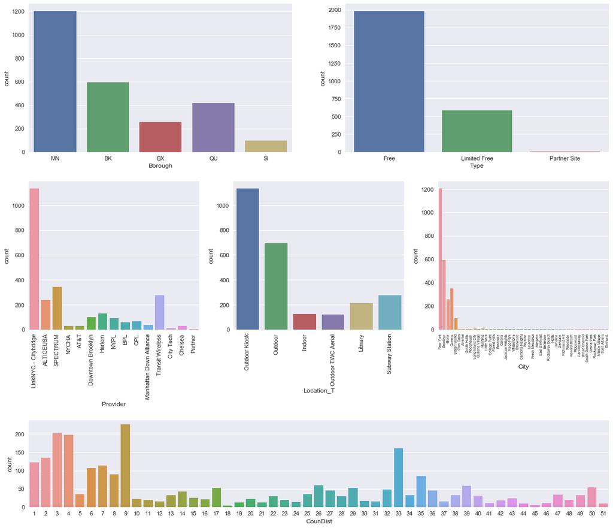

```python
fig = plt.figure(figsize=(18, 16), dpi = 80, facecolor='w', edgecolor='k')

## Add first figure in 3x3 grid (3x3,1)
ax1 = fig.add_subplot(321)
sns.countplot(x="Borough", data = nyc, ax=ax1)

ax2 = fig.add_subplot(322)
sns.countplot(x="Type", data = nyc, ax=ax2)

ax3 = fig.add_subplot(334)
g = sns.countplot(x="Provider",data=nyc, ax=ax3)
for item in g.get_xticklabels():
    item.set_rotation(90)

ax4 = fig.add_subplot(335)
g = sns.countplot(x="Location_T", data=nyc, ax=ax4)
for item in g.get_xticklabels():
    item.set_rotation(90)

ax5 = fig.add_subplot(336)
g = sns.countplot(x="City", data=nyc, ax=ax5)
for item in g.get_xticklabels():
    item.set_size(6)
    item.set_rotation(90)

ax7 = fig.add_subplot(515)
g = sns.countplot(x="CounDist", data=nyc, ax=ax7)
```

I will say that at a first go, visualization in Python is a little bit more difficult / unintuitive than data visualization in R. ggplot2 has really developed a strong, intuitive grammar for building graphics that Python doesn't seem to be able to compete with. It isn't to say that it takes longer, necessarily, but it's definitely a lot less intuitive. Building a plot layout isn't too bad, but modifying plot elements like axis text angle and size is pretty awkward / clunky.

I visualized most all the categorical variables that I thought might be interesting to visualize - the rest seemed unnecessary. We'll also tabulate these plots really quickly so I have exact counts.

## Some tabulations with pandas

```python
display(pd.DataFrame(nyc.Borough.value_counts()).transpose())
display(pd.DataFrame(nyc.Type.value_counts()).transpose())
display(pd.DataFrame(nyc.Provider.value_counts()).transpose())
display(pd.DataFrame(nyc.Location_T.value_counts()).transpose())
display(pd.DataFrame(nyc.City.value_counts()).transpose())
display(pd.DataFrame(nyc.CounDist.value_counts()).transpose())
```

|  | MN | BK | QU | BX | SI |
| --- | --- | --- | --- | --- | --- |
| Borough | 1204 | 595 | 415 | 257 | 95 |

|  | Free | Limited Free | Partner Site |
| --- | --- | --- | --- |
| Type | 1983 | 581 | 2 |

|  | LinkNYC - Citybridge | SPECTRUM | Transit Wireless | ALTICEUSA | Harlem | Downtown Brooklyn | NYPL | QPL | BPL | Manhattan Down Alliance | Chelsea | NYCHA | AT&T | City Tech | Partner |
| --- | --- | --- | --- | --- | --- | --- | --- | --- | --- | --- | --- | --- | --- | --- | --- |
| Provider | 1134 | 343 | 276 | 237 | 128 | 100 | 90 | 65 | 59 | 36 | 30 | 28 | 27 | 11 | 2 |

|  | Outdoor Kiosk | Outdoor | Subway Station | Library | Indoor | Outdoor TWC Aerial |
| --- | --- | --- | --- | --- | --- | --- |
| Location_T | 1134 | 696 | 276 | 214 | 125 | 121 |

|  | New York | Brooklyn | Queens | Bronx | Staten Island | Flushing | Long Island City | Jamaica | Bayside | Corona | ... | Ozone Park | Ridgewood | Rosedale | Rockaway Beach | Middle Village | Saint Albans | Maspeth | Queens Village | Woodside | Glendale |
| --- | --- | --- | --- | --- | --- | --- | --- | --- | --- | --- | --- | --- | --- | --- | --- | --- | --- | --- | --- | --- | --- |
| City | 1204 | 595 | 350 | 257 | 95 | 9 | 8 | 5 | 3 | 3 | ... | 1 | 1 | 1 | 1 | 1 | 1 | 1 | 1 | 1 | 1 |

1 rows × 44 columns

|  | 9 | 3 | 4 | 33 | 2 | 1 | 7 | 6 | 8 | 35 | ... | 12 | 24 | 21 | 19 | 46 | 41 | 44 | 51 | 45 | 18 |
| --- | --- | --- | --- | --- | --- | --- | --- | --- | --- | --- | --- | --- | --- | --- | --- | --- | --- | --- | --- | --- | --- |
| CounDist | 226 | 202 | 198 | 161 | 135 | 122 | 113 | 106 | 90 | 85 | ... | 15 | 14 | 12 | 12 | 11 | 11 | 9 | 9 | 6 | 4 |

1 rows × 51 columns

The boroughs, ranked from greatest to least in terms of number of Wi-Fi hotspots, are: Manhattan, Brooklyn, Queens, the Bronx, and Staten Island. Manhattan has 1,204 Wi-Fi hotspots, Brooklyn has 595 Wi-Fi hotspots, Queens has 415 Wi-Fi hotspots, the Bronx has 257 Wi-Fi hotspots, and Staten Island has 95.

Seeing this, a few questions that come to mind are:

- How does the number of hotspots relate to borough population (residential)?
- How does the number of hotspots relate to wealth of borough residents?
- How does the number of hotspots relate to borough labor force?

I do have Zip Code data in this dataset, so I'll place these questions at the bottom of the notebook for now to return to when I finish up with visualizations. Ideally, I'll be able to join some demographic data and see if any of them are correlated with the number of Wi-Fi hotspots. We'll probably have to do it at the Zip Code level, though, because if we do it at the borough level I'll have a sample size of only 5 boroughs which isn't too promising.

We also see that most 1983 Wi-Fi hotspots are free, 581 are limited free, and 2 hotspots in this dataset are partner site hotspots. One thing we can try to do is map out where free hotspots are vs. limited free hotspots, and see if they're clustered in certain areas. This can also be quickly computed via a cross-tabulation of Borough vs. Type, actually:

```python
pd.crosstab(index=nyc.Borough,columns=nyc.Type, normalize='index')
```

| Type Borough | Free | Limited Free | Partner Site |
| --- | --- | --- | --- |
| BK | 0.731092 | 0.268908 | 0.000000 |
| BX | 0.533074 | 0.466926 | 0.000000 |
| MN | 0.917774 | 0.080565 | 0.001661 |
| QU | 0.633735 | 0.366265 | 0.000000 |
| SI | 0.452632 | 0.547368 | 0.000000 |

Here I computed the relative proportion of free Wi-Fi hotspots to limited free Wi-Fi hotspots in each Borough, which may be a better way of understanding how access differs across boroughs. We recall that in terms of the number of hotspots, the boroughs, ranked from greatest to least, are Manhattan, Brooklyn, Queens, the Bronx, and Staten Island.

What this cross-tabulation shows us is that in terms of ratio from free hotspots to limited free hotspots, the ranking of the Boroughs is preserved showing that Staten Island not only has the least absolute number of hotspots, but it also has the least proportional access to free hotspots when comparing between boroughs.

This dataset is actually pretty nice because I can create quite a few interesting cross tabulations between the categorical variables.

```python
display(pd.crosstab(index=nyc.Borough,columns=nyc.Provider))
display(pd.crosstab(index=nyc.Type,columns=nyc.Provider))
display(pd.crosstab(index=nyc.Borough,columns=nyc.Location_T))
```

| Provider Borough | ALTICEUSA | AT&T | BPL | Chelsea | City Tech | Downtown Brooklyn | Harlem | LinkNYC - Citybridge | Manhattan Down Alliance | NYCHA | NYPL | Partner | QPL | SPECTRUM | Transit Wireless |
| --- | --- | --- | --- | --- | --- | --- | --- | --- | --- | --- | --- | --- | --- | --- | --- |
| BK | 117 | 7 | 59 | 0 | 11 | 100 | 0 | 150 | 0 | 28 | 0 | 0 | 0 | 43 | 80 |
| BX | 120 | 3 | 0 | 0 | 0 | 0 | 0 | 78 | 0 | 0 | 35 | 0 | 0 | 0 | 21 |
| MN | 0 | 12 | 0 | 30 | 0 | 0 | 128 | 711 | 36 | 0 | 43 | 2 | 0 | 97 | 145 |
| QU | 0 | 3 | 0 | 0 | 0 | 0 | 0 | 166 | 0 | 0 | 0 | 0 | 65 | 151 | 30 |
| SI | 0 | 2 | 0 | 0 | 0 | 0 | 0 | 29 | 0 | 0 | 12 | 0 | 0 | 52 | 0 |

| Provider Type | ALTICEUSA | AT&T | BPL | Chelsea | City Tech | Downtown Brooklyn | Harlem | LinkNYC - Citybridge | Manhattan Down Alliance | NYCHA | NYPL | Partner | QPL | SPECTRUM | Transit Wireless |
| --- | --- | --- | --- | --- | --- | --- | --- | --- | --- | --- | --- | --- | --- | --- | --- |
| Free | 0 | 26 | 59 | 30 | 11 | 100 | 128 | 1134 | 36 | 28 | 90 | 0 | 65 | 0 | 276 |
| Limited Free | 237 | 1 | 0 | 0 | 0 | 0 | 0 | 0 | 0 | 0 | 0 | 0 | 0 | 343 | 0 |
| Partner Site | 0 | 0 | 0 | 0 | 0 | 0 | 0 | 0 | 0 | 0 | 0 | 2 | 0 | 0 | 0 |

| Location_T Borough | Indoor | Library | Outdoor | Outdoor Kiosk | Outdoor TWC Aerial | Subway Station |
| --- | --- | --- | --- | --- | --- | --- |
| BK | 28 | 59 | 261 | 150 | 17 | 80 |
| BX | 13 | 35 | 110 | 78 | 0 | 21 |
| MN | 54 | 43 | 249 | 711 | 2 | 145 |
| QU | 22 | 65 | 46 | 166 | 86 | 30 |
| SI | 8 | 12 | 30 | 29 | 16 | 0 |

The main Wi-Fi provider in Manhattan LinkNYC-Citybridge. LinkNYC-CityBridge, ALTICEUSA, and Downtown Brooklyn are strong providers in Brooklyn, ALTICEUSA and LinkNYC-Citybridge are strong providers in the Bronx and LinkNYC-CityBridge and SPECTRUM are the strongest providers in Queens. SPECTRUM is the largest provider in Staten Island.

However, we note that SPECTRUM and ALTICEUSA are both Limited Free providers, which definitely affects Wi-Fi access in the boroughs they serve.

Most Wi-Fi hotspots in Manhattan and Queens are in outdoor kiosks, most Wi-Fi hotspots in Brooklyn and the Bronx are outdoors, and Staten Island has mostly outdoor hotspots but honestly just not many at all. We also note that the LinkNYC-Citybridge numbers from the Borough/Provider crosstab matches up with the Outdoor Kiosk column in the Borough/Location_T crosstab. Maybe it's just that Staten Island doesn't have enough payphones to convert to LinkNYC kiosks - also, I didn't even know that this was a thing! (see: https://www.link.nyc/)

```python
## Convert Activated variable to datetime
nyc.loc[:,'Activated'] = pd.to_datetime(nyc.Activated)
```

```python
## Can't plot this way, nice try

# nyc.Activated.sort_values()
#fig2 = plt.figure(figsize=(18, 4), dpi = 80, facecolor='w', edgecolor='k')

#ax1 = fig2.add_subplot(111)
#g = sns.countplot(x='Activated', data=nyc, ax=ax1)
#for item in g.get_xticklabels():
#    item.set_size(4)
#    item.set_rotation(90)
```

```python
counts = nyc.Activated.value_counts()
d = { 'count' : counts, 'index' : counts.index }
d = pd.DataFrame(d)
```

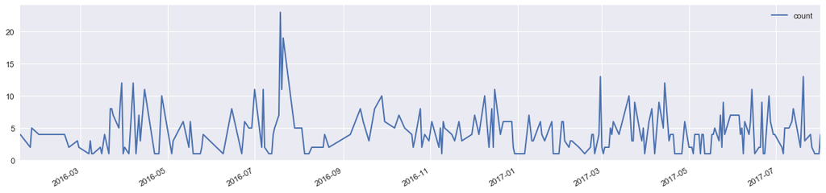

```python
fig2 = plt.figure(figsize=(18, 4), dpi = 80, facecolor='w', edgecolor='k')

ax1 = fig2.add_subplot(111)
d.plot(ax=ax1)
```

Okay, this was surprisingly easy. At first I was trying to use seaborn to plot a time-series plot, but that type of plot has a lot of specifications and a countplot also didn't suffice, so I used the built-in pandas DataFrame plot method to plot this time series of when Wi-Fi kiosks in New York were activated. They seem to have been being built pretty regularly from the start of this dataset, with a few spikes here and there - in particuarly, late July/early August of 2016 seems to have been particularly productive.

## How does the number of hotspots relate to ZIP code population (residential)?

To answer this question, I obtained some data from the ACS Community Survey. I pulled data on population, household income, per capita income and employment. I've done some preparation of that dataset not included here because it's mainly just dropping weird additional columns and variables that don't need to be involved, but here is the ACS community survey after import. I called the data "census_dat", but it's not really census data, so we'll also just ignore that misnomer. What I'll do now is merge that data onto the counts of hotspots in each ZIP code.

```python
census_dat = pd.read_csv("./census.csv", delimiter="\t")
```

```python
census_dat.head()
```

|  | ZIP Code Tabulation Area (5-digit) | Total Population | Population 16 Years and Over: | Population 16 Years and Over: in Labor Force | Population 16 Years and Over: in Labor Force: in Armed Forces | Population 16 Years and Over: in Labor Force: Civilian | Population 16 Years and Over: in Labor Force: Civilian: Employed | Population 16 Years and Over: in Labor Force: Civilian: Unemployed | Population 16 Years and Over: Not in Labor Force | Households: | ... | Households: $50,000 to $59,999 | Households: $60,000 to $74,999 | Households: $75,000 to $99,999 | Households: $100,000 to $124,999 | Households: $125,000 to $149,999 | Households: $150,000 to $199,999 | Households: $200,000 or More | Median Household Income (In 2015 Inflation Adjusted Dollars) | Average Household Income (In 2015 Inflation Adjusted Dollars) | Per Capita Income (In 2015 Inflation Adjusted Dollars) |
| --- | --- | --- | --- | --- | --- | --- | --- | --- | --- | --- | --- | --- | --- | --- | --- | --- | --- | --- | --- | --- | --- |
| 0 | 601 | 17982 | 14262 | 6162 | 0 | 6162 | 3949 | 2213 | 8100 | 5972 | ... | 231 | 138 | 86 | 59 | 22 | 20 | 28 | 10816.0 | 20349.497656 | 7453.0 |
| 1 | 602 | 40260 | 32723 | 15289 | 27 | 15262 | 11455 | 3807 | 17434 | 12968 | ... | 510 | 486 | 370 | 104 | 40 | 0 | 0 | 16079.0 | 23282.256323 | 8474.0 |
| 2 | 603 | 52408 | 42534 | 17058 | 43 | 17015 | 13024 | 3991 | 25476 | 18674 | ... | 933 | 691 | 454 | 217 | 121 | 109 | 110 | 16804.0 | 26819.856485 | 10179.0 |
| 3 | 606 | 6331 | 5041 | 1679 | 0 | 1679 | 1500 | 179 | 3362 | 1915 | ... | 27 | 7 | 0 | 0 | 0 | 0 | 0 | 12512.0 | 15729.817232 | 5863.0 |
| 4 | 610 | 28328 | 22988 | 9542 | 0 | 9542 | 8047 | 1495 | 13446 | 9404 | ... | 395 | 311 | 151 | 43 | 23 | 26 | 0 | 17475.0 | 23359.761803 | 8452.0 |

5 rows × 29 columns

```python
census_dat.to_csv("./census.csv", sep="\t", index=False)
```

```python
zips = nyc.Postcode.value_counts()
d = { 'zip': zips.index, 'count': zips }
d = pd.DataFrame(d)
d.reset_index(inplace=True)
d.drop(d.columns[0], axis=1, inplace=True)
```

```python
census_dat = census_dat.rename(index = str, columns = { "ZIP Code Tabulation Area (5-digit)" : "zip" })
```

I'll note here for myself that usually we would want to make sure the zip code was imported as a string or padded with leading zeros, but it's okay in this case because zip codes in New York City all start with 1.

```python
d = d.merge(census_dat, how='left', on='zip')
display(d)
```

|  | count | zip | Total Population | Population 16 Years and Over: | Population 16 Years and Over: in Labor Force | Population 16 Years and Over: in Labor Force: in Armed Forces | Population 16 Years and Over: in Labor Force: Civilian | Population 16 Years and Over: in Labor Force: Civilian: Employed | Population 16 Years and Over: in Labor Force: Civilian: Unemployed | Population 16 Years and Over: Not in Labor Force | ... | Households: $50,000 to $59,999 | Households: $60,000 to $74,999 | Households: $75,000 to $99,999 | Households: $100,000 to $124,999 | Households: $125,000 to $149,999 | Households: $150,000 to $199,999 | Households: $200,000 or More | Median Household Income (In 2015 Inflation Adjusted Dollars) | Average Household Income (In 2015 Inflation Adjusted Dollars) | Per Capita Income (In 2015 Inflation Adjusted Dollars) |
| --- | --- | --- | --- | --- | --- | --- | --- | --- | --- | --- | --- | --- | --- | --- | --- | --- | --- | --- | --- | --- | --- |
| 0 | 152 | 11201 | 58350.0 | 50208.0 | 35113.0 | 0.0 | 35113.0 | 32803.0 | 2310.0 | 15095.0 | ... | 1211.0 | 1611.0 | 2685.0 | 2341.0 | 1921.0 | 2810.0 | 5926.0 | 101150.0 | 152775.268859 | 68420.0 |
| 1 | 91 | 10027 | 64413.0 | 53567.0 | 28253.0 | 19.0 | 28234.0 | 26365.0 | 1869.0 | 25314.0 | ... | 1501.0 | 1409.0 | 2206.0 | 1272.0 | 971.0 | 1111.0 | 1528.0 | 40782.0 | 70033.513537 | 26953.0 |
| 2 | 72 | 10011 | 52349.0 | 47220.0 | 36403.0 | 0.0 | 36403.0 | 34624.0 | 1779.0 | 10817.0 | ... | 1254.0 | 1594.0 | 2492.0 | 2952.0 | 2218.0 | 3278.0 | 8116.0 | 109818.0 | 196816.964586 | 114034.0 |
| 3 | 70 | 10003 | 57112.0 | 53824.0 | 36392.0 | 0.0 | 36392.0 | 34170.0 | 2222.0 | 17432.0 | ... | 1328.0 | 2253.0 | 3103.0 | 2496.0 | 1682.0 | 3194.0 | 6197.0 | 98151.0 | 161691.545094 | 80936.0 |
| 4 | 61 | 10025 | 96068.0 | 83593.0 | 54419.0 | 29.0 | 54390.0 | 50045.0 | 4345.0 | 29174.0 | ... | 2045.0 | 3229.0 | 4226.0 | 2978.0 | 2946.0 | 3907.0 | 7512.0 | 74065.0 | 124739.198270 | 58664.0 |
| 5 | 60 | 10019 | 38830.0 | 36188.0 | 26614.0 | 0.0 | 26614.0 | 25097.0 | 1517.0 | 9574.0 | ... | 1091.0 | 1670.0 | 2480.0 | 1807.0 | 1659.0 | 2274.0 | 5022.0 | 94022.0 | 144752.782338 | 89202.0 |
| 6 | 51 | 10022 | 30607.0 | 28068.0 | 19814.0 | 31.0 | 19783.0 | 18887.0 | 896.0 | 8254.0 | ... | 523.0 | 1312.0 | 1746.0 | 1449.0 | 1295.0 | 1836.0 | 5939.0 | 126378.0 | 234492.264699 | 139507.0 |
| 7 | 48 | 10001 | 23537.0 | 20936.0 | 14785.0 | 0.0 | 14785.0 | 13550.0 | 1235.0 | 6151.0 | ... | 439.0 | 546.0 | 1141.0 | 1032.0 | 507.0 | 1168.0 | 2578.0 | 86801.0 | 158183.366269 | 80990.0 |
| 8 | 48 | 10016 | 50641.0 | 46526.0 | 35124.0 | 0.0 | 35124.0 | 33378.0 | 1746.0 | 11402.0 | ... | 1379.0 | 2062.0 | 2899.0 | 3256.0 | 2191.0 | 3063.0 | 6431.0 | 104826.0 | 152943.518845 | 88937.0 |
| 9 | 48 | 10023 | 60586.0 | 52418.0 | 36606.0 | 0.0 | 36606.0 | 34822.0 | 1784.0 | 15812.0 | ... | 1033.0 | 2049.0 | 3238.0 | 3205.0 | 2237.0 | 3798.0 | 9030.0 | 111478.0 | 188599.975576 | 103249.0 |
| 10 | 46 | 10031 | 59244.0 | 50563.0 | 34229.0 | 0.0 | 34229.0 | 30571.0 | 3658.0 | 16334.0 | ... | 1551.0 | 1761.0 | 2153.0 | 1100.0 | 822.0 | 645.0 | 596.0 | 39774.0 | 56923.986598 | 23542.0 |
| 11 | 45 | 10026 | 38310.0 | 31053.0 | 19140.0 | 9.0 | 19131.0 | 17462.0 | 1669.0 | 11913.0 | ... | 891.0 | 1264.0 | 1051.0 | 1010.0 | 676.0 | 910.0 | 1104.0 | 47264.0 | 79815.309424 | 32424.0 |
| 12 | 43 | 10029 | 79251.0 | 64889.0 | 37312.0 | 0.0 | 37312.0 | 32792.0 | 4520.0 | 27577.0 | ... | 1804.0 | 2005.0 | 2207.0 | 1458.0 | 712.0 | 853.0 | 1382.0 | 31350.0 | 60756.363938 | 25697.0 |
| 13 | 37 | 10451 | 48188.0 | 36645.0 | 20047.0 | 28.0 | 20019.0 | 17043.0 | 2976.0 | 16598.0 | ... | 1054.0 | 1220.0 | 1166.0 | 621.0 | 219.0 | 180.0 | 234.0 | 26048.0 | 40835.970232 | 16487.0 |
| 14 | 37 | 10457 | 73763.0 | 53964.0 | 30448.0 | 17.0 | 30431.0 | 25407.0 | 5024.0 | 23516.0 | ... | 1355.0 | 1511.0 | 1281.0 | 579.0 | 294.0 | 267.0 | 103.0 | 24750.0 | 36604.370710 | 12997.0 |
| 15 | 36 | 11434 | 65892.0 | 52205.0 | 34124.0 | 9.0 | 34115.0 | 30236.0 | 3879.0 | 18081.0 | ... | 2243.0 | 2167.0 | 2584.0 | 2365.0 | 1299.0 | 1114.0 | 394.0 | 58076.0 | 70071.376200 | 23804.0 |
| 16 | 36 | 11215 | 70818.0 | 58238.0 | 45690.0 | 30.0 | 45660.0 | 43127.0 | 2533.0 | 12548.0 | ... | 1639.0 | 2518.0 | 3685.0 | 3330.0 | 2178.0 | 3823.0 | 5822.0 | 103716.0 | 144180.330341 | 60565.0 |
| 17 | 32 | 10024 | 58391.0 | 49674.0 | 35565.0 | 0.0 | 35565.0 | 34210.0 | 1355.0 | 14109.0 | ... | 1342.0 | 1832.0 | 2380.0 | 2539.0 | 1608.0 | 2998.0 | 8440.0 | 113839.0 | 202005.067132 | 101201.0 |
| 18 | 32 | 11224 | 43001.0 | 36379.0 | 18693.0 | 7.0 | 18686.0 | 15752.0 | 2934.0 | 17686.0 | ... | 1157.0 | 1364.0 | 1340.0 | 610.0 | 500.0 | 614.0 | 410.0 | 28006.0 | 50454.506200 | 22123.0 |
| 19 | 31 | 10037 | 18777.0 | 15041.0 | 8914.0 | 0.0 | 8914.0 | 7809.0 | 1105.0 | 6127.0 | ... | 809.0 | 835.0 | 1084.0 | 267.0 | 232.0 | 205.0 | 204.0 | 35491.0 | 50690.811286 | 25883.0 |
| 20 | 31 | 11101 | 25880.0 | 22183.0 | 15083.0 | 31.0 | 15052.0 | 13824.0 | 1228.0 | 7100.0 | ... | 826.0 | 626.0 | 1180.0 | 928.0 | 553.0 | 696.0 | 984.0 | 48013.0 | 77677.259599 | 36573.0 |
| 21 | 30 | 11217 | 38511.0 | 32809.0 | 24095.0 | 11.0 | 24084.0 | 22394.0 | 1690.0 | 8714.0 | ... | 747.0 | 1384.0 | 1881.0 | 1611.0 | 1433.0 | 1634.0 | 3031.0 | 87091.0 | 126829.231410 | 56447.0 |
| 22 | 29 | 10035 | 33920.0 | 28090.0 | 14625.0 | 0.0 | 14625.0 | 13100.0 | 1525.0 | 13465.0 | ... | 995.0 | 715.0 | 846.0 | 539.0 | 277.0 | 378.0 | 373.0 | 27424.0 | 47759.435341 | 20371.0 |
| 23 | 28 | 10030 | 29209.0 | 24086.0 | 15781.0 | 0.0 | 15781.0 | 13158.0 | 2623.0 | 8305.0 | ... | 758.0 | 1064.0 | 708.0 | 776.0 | 367.0 | 316.0 | 374.0 | 33196.0 | 53228.576234 | 23818.0 |
| 24 | 28 | 10017 | 16472.0 | 15487.0 | 12530.0 | 23.0 | 12507.0 | 12091.0 | 416.0 | 2957.0 | ... | 329.0 | 957.0 | 1027.0 | 1053.0 | 845.0 | 1033.0 | 2498.0 | 106421.0 | 160724.554494 | 102122.0 |
| 25 | 27 | 10018 | 9168.0 | 8515.0 | 6864.0 | 0.0 | 6864.0 | 6560.0 | 304.0 | 1651.0 | ... | 214.0 | 251.0 | 474.0 | 530.0 | 346.0 | 587.0 | 1078.0 | 105500.0 | 144418.845501 | 79765.0 |
| 26 | 26 | 11216 | 53747.0 | 46295.0 | 32418.0 | 19.0 | 32399.0 | 28563.0 | 3836.0 | 13877.0 | ... | 1923.0 | 2040.0 | 2413.0 | 1889.0 | 840.0 | 1105.0 | 880.0 | 47107.0 | 65961.849184 | 29655.0 |
| 27 | 26 | 10010 | 31447.0 | 29210.0 | 20674.0 | 60.0 | 20614.0 | 19417.0 | 1197.0 | 8536.0 | ... | 832.0 | 1288.0 | 1516.0 | 1406.0 | 1134.0 | 1395.0 | 4290.0 | 101718.0 | 154978.504673 | 82453.0 |
| 28 | 24 | 10306 | 54939.0 | 45275.0 | 26875.0 | 21.0 | 26854.0 | 25213.0 | 1641.0 | 18400.0 | ... | 1155.0 | 1698.0 | 2517.0 | 2378.0 | 1639.0 | 2448.0 | 1540.0 | 79686.0 | 95618.238931 | 35632.0 |
| 29 | 24 | 10032 | 62685.0 | 53011.0 | 33570.0 | 0.0 | 33570.0 | 29217.0 | 4353.0 | 19441.0 | ... | 1632.0 | 2058.0 | 1957.0 | 984.0 | 581.0 | 471.0 | 367.0 | 37280.0 | 52049.508472 | 19479.0 |
| ... | ... | ... | ... | ... | ... | ... | ... | ... | ... | ... | ... | ... | ... | ... | ... | ... | ... | ... | ... | ... | ... |
| 146 | 1 | 11422 | 33245.0 | 26146.0 | 18163.0 | 8.0 | 18155.0 | 16987.0 | 1168.0 | 7983.0 | ... | 756.0 | 763.0 | 1533.0 | 1362.0 | 870.0 | 1154.0 | 456.0 | 84955.0 | 92701.663202 | 28435.0 |
| 147 | 1 | 10475 | 43913.0 | 37808.0 | 21829.0 | 0.0 | 21829.0 | 19361.0 | 2468.0 | 15979.0 | ... | 1442.0 | 1811.0 | 1999.0 | 969.0 | 775.0 | 845.0 | 327.0 | 44923.0 | 59288.276504 | 26262.0 |
| 148 | 1 | 11428 | 19744.0 | 16564.0 | 10495.0 | 0.0 | 10495.0 | 9574.0 | 921.0 | 6069.0 | ... | 428.0 | 568.0 | 877.0 | 730.0 | 429.0 | 321.0 | 134.0 | 67151.0 | 75806.494662 | 22940.0 |
| 149 | 1 | 11414 | 28700.0 | 23866.0 | 14535.0 | 0.0 | 14535.0 | 13352.0 | 1183.0 | 9331.0 | ... | 845.0 | 1017.0 | 1530.0 | 900.0 | 683.0 | 1045.0 | 710.0 | 68374.0 | 88916.566548 | 34333.0 |
| 150 | 1 | 10307 | 15098.0 | 11690.0 | 7194.0 | 0.0 | 7194.0 | 6680.0 | 514.0 | 4496.0 | ... | 381.0 | 429.0 | 747.0 | 431.0 | 513.0 | 479.0 | 538.0 | 76857.0 | 96729.315068 | 33068.0 |
| 151 | 1 | 10103 | 0.0 | 0.0 | 0.0 | 0.0 | 0.0 | 0.0 | 0.0 | 0.0 | ... | 0.0 | 0.0 | 0.0 | 0.0 | 0.0 | 0.0 | 0.0 | NaN | NaN | NaN |
| 152 | 1 | 10107 | NaN | NaN | NaN | NaN | NaN | NaN | NaN | NaN | ... | NaN | NaN | NaN | NaN | NaN | NaN | NaN | NaN | NaN | NaN |
| 153 | 1 | 11369 | 39001.0 | 31763.0 | 20230.0 | 0.0 | 20230.0 | 18429.0 | 1801.0 | 11533.0 | ... | 777.0 | 1225.0 | 1713.0 | 831.0 | 482.0 | 638.0 | 245.0 | 52310.0 | 67171.111305 | 21184.0 |
| 154 | 1 | 11378 | 31756.0 | 26023.0 | 16928.0 | 0.0 | 16928.0 | 15431.0 | 1497.0 | 9095.0 | ... | 839.0 | 1542.0 | 1636.0 | 908.0 | 648.0 | 735.0 | 548.0 | 57127.0 | 74249.383611 | 30288.0 |
| 155 | 1 | 11364 | 34949.0 | 28805.0 | 17858.0 | 0.0 | 17858.0 | 16895.0 | 963.0 | 10947.0 | ... | 939.0 | 1467.0 | 1774.0 | 1679.0 | 803.0 | 1152.0 | 936.0 | 72477.0 | 88789.072321 | 34465.0 |
| 156 | 1 | 10282 | 5730.0 | 3955.0 | 3079.0 | 0.0 | 3079.0 | 3063.0 | 16.0 | 876.0 | ... | 67.0 | 101.0 | 198.0 | 167.0 | 70.0 | 138.0 | 1494.0 | 250001.0 | 318141.738417 | 137952.0 |
| 157 | 1 | 10154 | 0.0 | 0.0 | 0.0 | 0.0 | 0.0 | 0.0 | 0.0 | 0.0 | ... | 0.0 | 0.0 | 0.0 | 0.0 | 0.0 | 0.0 | 0.0 | NaN | NaN | NaN |
| 158 | 1 | 10308 | 29766.0 | 24981.0 | 15240.0 | 0.0 | 15240.0 | 13966.0 | 1274.0 | 9741.0 | ... | 660.0 | 1005.0 | 1591.0 | 1499.0 | 775.0 | 1364.0 | 819.0 | 87174.0 | 98768.599532 | 35768.0 |
| 159 | 1 | 10048 | NaN | NaN | NaN | NaN | NaN | NaN | NaN | NaN | ... | NaN | NaN | NaN | NaN | NaN | NaN | NaN | NaN | NaN | NaN |
| 160 | 1 | 10464 | 4723.0 | 3870.0 | 2474.0 | 0.0 | 2474.0 | 2305.0 | 169.0 | 1396.0 | ... | 180.0 | 224.0 | 202.0 | 297.0 | 168.0 | 236.0 | 112.0 | 75208.0 | 90670.503953 | 38931.0 |
| 161 | 1 | 10470 | 14868.0 | 12122.0 | 7872.0 | 9.0 | 7863.0 | 6948.0 | 915.0 | 4250.0 | ... | 458.0 | 521.0 | 860.0 | 637.0 | 280.0 | 326.0 | 155.0 | 57706.0 | 70508.752393 | 28806.0 |
| 162 | 1 | 10472 | 68654.0 | 51872.0 | 30816.0 | 0.0 | 30816.0 | 26854.0 | 3962.0 | 21056.0 | ... | 1440.0 | 1569.0 | 1573.0 | 944.0 | 559.0 | 330.0 | 71.0 | 29308.0 | 41908.515233 | 14443.0 |
| 163 | 1 | 10474 | 12686.0 | 9368.0 | 4599.0 | 0.0 | 4599.0 | 3961.0 | 638.0 | 4769.0 | ... | 218.0 | 277.0 | 173.0 | 94.0 | 56.0 | 6.0 | 19.0 | 26585.0 | 36170.827567 | 11884.0 |
| 164 | 1 | 11004 | 13778.0 | 11875.0 | 7242.0 | 0.0 | 7242.0 | 6735.0 | 507.0 | 4633.0 | ... | 263.0 | 402.0 | 871.0 | 442.0 | 573.0 | 587.0 | 347.0 | 85968.0 | 99829.638009 | 37119.0 |
| 165 | 1 | 11417 | 32415.0 | 26102.0 | 16963.0 | 0.0 | 16963.0 | 15068.0 | 1895.0 | 9139.0 | ... | 894.0 | 1081.0 | 1282.0 | 909.0 | 636.0 | 609.0 | 468.0 | 62057.0 | 79019.883598 | 24249.0 |
| 166 | 1 | 11413 | 42560.0 | 34406.0 | 22997.0 | 13.0 | 22984.0 | 20929.0 | 2055.0 | 11409.0 | ... | 700.0 | 1327.0 | 2017.0 | 1328.0 | 1203.0 | 1450.0 | 715.0 | 81287.0 | 92537.985250 | 28943.0 |
| 167 | 1 | 11411 | 19208.0 | 16301.0 | 10269.0 | 21.0 | 10248.0 | 9588.0 | 660.0 | 6032.0 | ... | 427.0 | 727.0 | 779.0 | 828.0 | 594.0 | 645.0 | 327.0 | 81149.0 | 93446.595815 | 31421.0 |
| 168 | 1 | 11230 | 88589.0 | 66750.0 | 38477.0 | 18.0 | 38459.0 | 35100.0 | 3359.0 | 28273.0 | ... | 1851.0 | 2694.0 | 2874.0 | 1741.0 | 1117.0 | 1432.0 | 1615.0 | 41068.0 | 66631.611914 | 23673.0 |
| 169 | 1 | 10302 | 18286.0 | 14013.0 | 8151.0 | 0.0 | 8151.0 | 7600.0 | 551.0 | 5862.0 | ... | 368.0 | 438.0 | 879.0 | 398.0 | 377.0 | 428.0 | 271.0 | 54170.0 | 70738.690377 | 23486.0 |
| 170 | 1 | 11367 | 42667.0 | 33151.0 | 19845.0 | 10.0 | 19835.0 | 18354.0 | 1481.0 | 13306.0 | ... | 1362.0 | 1524.0 | 1623.0 | 1366.0 | 855.0 | 1048.0 | 556.0 | 56557.0 | 73717.577165 | 26129.0 |
| 171 | 1 | 11361 | 30207.0 | 25317.0 | 16300.0 | 5.0 | 16295.0 | 14966.0 | 1329.0 | 9017.0 | ... | 801.0 | 973.0 | 1539.0 | 1405.0 | 766.0 | 1066.0 | 780.0 | 79158.0 | 93310.352631 | 34071.0 |
| 172 | 1 | 11357 | 39737.0 | 32848.0 | 19438.0 | 10.0 | 19428.0 | 17757.0 | 1671.0 | 13410.0 | ... | 955.0 | 1807.0 | 2144.0 | 1795.0 | 1031.0 | 1392.0 | 947.0 | 73750.0 | 91915.404823 | 35216.0 |
| 173 | 1 | 11356 | 24631.0 | 19491.0 | 12442.0 | 17.0 | 12425.0 | 11460.0 | 965.0 | 7049.0 | ... | 703.0 | 721.0 | 1272.0 | 640.0 | 335.0 | 419.0 | 330.0 | 57194.0 | 75111.657158 | 24718.0 |
| 174 | 1 | 11360 | 19605.0 | 16576.0 | 9507.0 | 0.0 | 9507.0 | 8813.0 | 694.0 | 7069.0 | ... | 651.0 | 683.0 | 1194.0 | 1019.0 | 536.0 | 937.0 | 831.0 | 80235.0 | 97078.043656 | 43302.0 |
| 175 | 1 | 10123 | NaN | NaN | NaN | NaN | NaN | NaN | NaN | NaN | ... | NaN | NaN | NaN | NaN | NaN | NaN | NaN | NaN | NaN | NaN |

176 rows × 30 columns

Cool, pretty seamless merge. There are a few rows that weren't in the ACS data, so we note those and prepare to drop them or ignore them if necessary. So now we can play around with some simple regressions in Python and see how they compare to R!

## Some simple regressions

I don't think it's super obvious to me how to do a regression in Python, so I'm going to walk through this with this resource here. https://medium.com/towards-data-science/simple-and-multiple-linear-regression-in-python-c928425168f9

```python
import statsmodels.api as sm
```

```python
d2 = d.dropna()
```

```python
## Target or response variable / count
target = pd.DataFrame(d2.loc[:,"count"],columns=["count"])

## Features - everything except for ZIP
popfeatures = d2.loc[:,["Total Population"]]
```

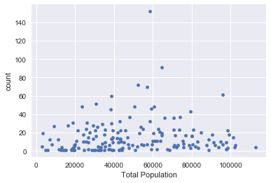

```python
d2.plot(x="Total Population", y="count", kind="scatter")
```

Because it's only a simple linear regression, we can use a scatter plot to get an idea of what we should expect to see out of the regression. We don't really see an extremely positive or negative relationship - however, it does seem like zip codes that are populated around the middle of the range tend to have more hotspots in their zip code.

```python
model = sm.OLS(target.loc[:,"count"], popfeatures.loc[:,"Total Population"]).fit()
model.summary()
```

OLS Regression Results

| Dep. Variable: | count | R-squared: | 0.347 |
| --- | --- | --- | --- |
| Model: | OLS | Adj. R-squared: | 0.343 |
| Method: | Least Squares | F-statistic: | 88.09 |
| Date: | Thu, 07 Sep 2017 | Prob (F-statistic): | 4.70e-17 |
| Time: | 11:52:43 | Log-Likelihood: | -733.03 |
| No. Observations: | 167 | AIC: | 1468. |
| Df Residuals: | 166 | BIC: | 1471. |
| Df Model: | 1 |  |  |
| Covariance Type: | nonrobust |  |  |

|  | coef | std err | t | P>\|t\| | [0.025 | 0.975] |
| --- | --- | --- | --- | --- | --- | --- |
| Total Population | 0.0003 | 2.7e-05 | 9.386 | 0.000 | 0.000 | 0.000 |

| Omnibus: | 131.240 | Durbin-Watson: | 0.289 |
| --- | --- | --- | --- |
| Prob(Omnibus): | 0.000 | Jarque-Bera (JB): | 1577.845 |
| Skew: | 2.808 | Prob(JB): | 0.00 |
| Kurtosis: | 16.972 | Cond. No. | 1.00 |

As far as regression goes, I don't really like this display more at all. R definitely wins so far when it comes to regression. The setup isn't really intuitive at all. I suppose you might be able to get used to it, though? Anyway, when it comes to the regression results, I see that it would have probably have been smarter to standardize the units of the predictor, because it's not really too useful for us to say that an increase in 1 person in population is approximately associated with an increase in 0.0003 of a Wi-Fi hotspot in a zip code, holding everything else fixed.

We multiply 0.0003 by 10,000 and 1 by 10,000 to get that an approximate increase in 10,000 residents is associated with an approximate increase in 3 Wi-Fi hotspots, holding all else fixed, which is a more interpretable number. The R-squared value shows us that this model explains only approximately 34.7% of the variation in the response, which isn't too shabby, but it's not great either.

## How does the number of hotspots relate to wealth of ZIP code residents?

```python
## Predictors - population, median, average, and per capita income
X = d2.iloc[:,[2,27,28,29]]
y = target.loc[:,"count"]

## Scale the response
y = y * 10000

## Fit model and display summary
model = sm.OLS(y, X).fit()
model.summary()
```

OLS Regression Results

| Dep. Variable: | count | R-squared: | 0.516 |
| --- | --- | --- | --- |
| Model: | OLS | Adj. R-squared: | 0.504 |
| Method: | Least Squares | F-statistic: | 43.46 |
| Date: | Thu, 07 Sep 2017 | Prob (F-statistic): | 8.80e-25 |
| Time: | 12:08:12 | Log-Likelihood: | -2246.1 |
| No. Observations: | 167 | AIC: | 4500. |
| Df Residuals: | 163 | BIC: | 4513. |
| Df Model: | 4 |  |  |
| Covariance Type: | nonrobust |  |  |

|  | coef | std err | t | P>\|t\| | [0.025 | 0.975] |
| --- | --- | --- | --- | --- | --- | --- |
| Total Population | 1.9822 | 0.350 | 5.663 | 0.000 | 1.291 | 2.673 |
| Median Household Income (In 2015 Inflation Adjusted Dollars) | -1.8849 | 1.258 | -1.498 | 0.136 | -4.369 | 0.599 |
| Average Household Income (In 2015 Inflation Adjusted Dollars) | -0.5379 | 1.411 | -0.381 | 0.703 | -3.324 | 2.248 |
| Per Capita Income (In 2015 Inflation Adjusted Dollars) | 5.5684 | 1.703 | 3.270 | 0.001 | 2.206 | 8.931 |

| Omnibus: | 157.712 | Durbin-Watson: | 0.549 |
| --- | --- | --- | --- |
| Prob(Omnibus): | 0.000 | Jarque-Bera (JB): | 3448.084 |
| Skew: | 3.381 | Prob(JB): | 0.00 |
| Kurtosis: | 24.208 | Cond. No. | 24.9 |

The multiple linear regression with population, median, average, and per capita income as predictors is able to explain about 50% of the variation in the response, which is pretty promising. For a zip code, it turns out that per capita income is a pretty damn strong predictor of how many Wi-Fi hotspots are in an area. This makes sense - I feel like per capita income is often the best measure of the overall wealth in an area. Every 10,000 increase in per capita income in a zip code is associated with approximately 5 Wi-Fi hotspots.

In this regression, the coefficients for median and average household income aren't significantly different from zero statistically.

The coefficient for population is still significantly different from zero, with a 10,000 increase in population approximately associated with about 2 additional Wi-Fi hotspots.

Anyway, that's enough regression. Python has been interesting to explore, but I'll just note that regression is significantly more difficult in Python and there really isn't an easy way to perform regression diagnostics.

First of all, I know I shouldn't really even be using linear regression necessarily because my response variable is a count, but also, a quick Google search on "Python residual plots" yields less than 150k results as opposed to "R residual plots" yielding 1M+. A Google search on "Python regression diagnostics" yields less than 66k results as opposed to "R regression diagnostics" yielding 660k+. It's pretty clear people aren't really using Python for linear regression, which is a bummer.

Anyway, this has been a pretty fun exploration of Wi-Fi hotspot data.

## Some key takeaways I got:

- Manhattan > Brooklyn > Queens > Bronx > Staten Island, in terms of Wi-Fi.
- When we talk about Wi-Fi accessibility, it's still not really equitable and that's clearly reflected in this data and *where* these resources are located compared to the demographics of each ZIP in NYC, from cross-tabs, visualizations and the simple regression.
- Umm... NYC has Wi-Fi kiosks?

## To be continued, maybe:

- Mapping in Python.